# Car Selling Price

2024-01-23

# Cat Eye Chevy Pickups

```r
library(tidyverse)
library(pander)
library(DT)
library(dplyr)
library(zoo)
library(car)
```

```r
cateye <- data.frame("year" = c(2004,2005,2005,2005,2003,2005,2004,2006,2004,2004,2004,2005,2006,2003,2003,2006,2006,2006,2006,2006,2006,2006,2006,2005,2006,2006,2005,2003,2005,2004,2006,2005),
                     "Trim" = c("NA","NA","LS","LS","NA","NA","NA","LS","LS","NA","NA","NA","NA","LS","NA","LT","LT","NA","LS","NA","LS","LS","NA","LS","LT","NA","LS","NA","Base","NA","NA","NA"),
                     "Cab" = c("Crew","Crew","Extended","Extended","Crew","Extended","Crew","Extended","Extended","Extended","Crew","Extended","Extended","Extended","Extended","Crew","Crew","Crew","Extended","Extended","Single","Extended","Crew","Extended","Extended","Crew","Extended","Extended","Extended","Extended","Extended","Extended"),
                     "Mileage" = c(167886,245852,175262,125697,129228,62523,228000,121000,230000, 234000,167000,243000,363000,286000,165000,183000,224447,247603,44484,62278,78011,82853,83403,399917,354000,348038,332410,313000,299630,297039,294000,290541),
                     "Price" = c(8995,8294,10257,11978,15990,18995,5000,6000,5500,7500,8995,5400,4000,3695,12500,9995,6995,8991,12999,9995,11995,12995,14995,7450,4250,5990,6250,7900,3795,6295,4900,3998))
```

### Show Data

Here’s the data that I collect from numerous sources provided as well as some on facebook marketplace. I gathered mostly information on pickups within the 2003-2006 years as well as those that are classified as 1500 and put an emphasis on those with 5.3L Vortec motors.

```r
datatable(cateye, options=list(lengthMenu = c(3,10,30),scrollY=300,scroller=TRUE,scrollX=TRUE),
            extensions="Scroller")
```

|  | year | Trim | Cab | Mileage | Price |
| --- | --- | --- | --- | --- | --- |
| 1 | 2004 | NA | Crew | 167886 | 8995 |
| 2 | 2005 | NA | Crew | 245852 | 8294 |
| 3 | 2005 | LS | Extended | 175262 | 10257 |
| 4 | 2005 | LS | Extended | 125697 | 11978 |
| 5 | 2003 | NA | Crew | 129228 | 15990 |
| 6 | 2005 | NA | Extended | 62523 | 18995 |
| 7 | 2004 | NA | Crew | 228000 | 5000 |
| 8 | 2006 | LS | Extended | 121000 | 6000 |
| 9 | 2004 | LS | Extended | 230000 | 5500 |
| 10 | 2004 | NA | Extended | 234000 | 7500 |

[output cut: 22 more lines]

## Quick Read

### Summary

[figure not shown]

```r
cateye_plot
```

When looking at our linear model we determined that it was a logical falacy that the value of your vehicle would become negative as the miles keep tacking on, so after determining to alter the regression with the log(x) function based off our findings from the boxCox() methods. This it the curve that we came out with. The plot above shows the predicted values for each of the lines displayed as well as the prediction interval band for the predicted values at the specified values of 190K miles, showing that we’d could expect to find the values for such x values anywhere within these prediction intervals.

## Full Analysis

### Background

I am keen on evaluating the resale value of Cat Eye Chevy Pickups, specifically those from 2003 to 2006. The term ‘Cat Eye’ refers to the distinctive aesthetic of these pickups, characterized by their grill and headlights, giving them an assertive appearance. I tend to focus on the potential resale value when purchasing vehicles, including cars, pickups, motorcycles, or dirt bikes. I usually opt for older models based on general observations. When assessing the resale value of these Chevy pickups, factors such as overall condition, mileage, maintenance history, modifications, and current market demand come into play. Maintaining the vehicle, documenting regular maintenance, and being mindful of market trends are key considerations for maximizing resale value. In addition, understanding model-specific details and local market factors can provide valuable insights for an informed analysis. Here’s an image below:

[figure not shown]

### My Case

When considering the potential purchase of this style of truck, I noticed they retained significant value despite their age and mileage. After some research, I came across information suggesting that they were produced just before emissions regulations became more stringent.

In my specific case, leveraging my mechanical knowledge, I undertook a unique project by combining two different trucks into one. I found a severely damaged truck on Facebook Marketplace, with the back of the cab and bed destroyed due to a fallen tree, priced at $400$. However, the engine had lower mileage. Subsequently, I acquired another truck with a well-preserved body, considering it was in the rust belt, for $2000$. The engine swap went smoothly, and I invested a total of $2400$ to restore it to good running condition.

The purpose of this analysis is to evaluate the soundness of my decision and determine a potential selling price for the truck.

### Linear Regression

For our hypothesis we will be focused on the relationship between mileage and price for Cateye Trucks. Starting out we can describe our linear regression model in the format:

$$\underbrace{Y_i}_\text{Price} = \beta_0 + \beta_1
\underbrace{X_i}_\text{Mileage} + \epsilon_i \quad \text{where} \
\epsilon_i \sim N(0, \sigma^2)$$

Our hypothesis will take a look at the $\beta_0$ (y-int) and the $\beta_1$ (slope).

### Intercept Hypothesis

For our intercept hypothesis or $\beta_0$ hypothesis, we aim to investigate whether the intercept plays a role in the relationship between the price and mileage of Cat Eye pickups. We have established a standard significance level of$\alpha = 0.05$.

$$H_0: \beta_0 = 0$$
$$H_a: \beta_0 \neq 0$$
$$\alpha = 0.05$$

### Slope Hypethsis

In our slope hypothesis or our $\beta_1$ hypothesis, our null hypothesis aligns with the alternate hypothesis. In this scenario, rejecting the null hypothesis would lead us to conclude a significant linear relationship between the independent and dependent variables. Our chosen significance level is $\alpha = 0.05$.

$$H_0: \beta_1 = 0$$
$$H_a: \beta_1 \neq 0$$
$$\alpha = 0.05$$

### Execution

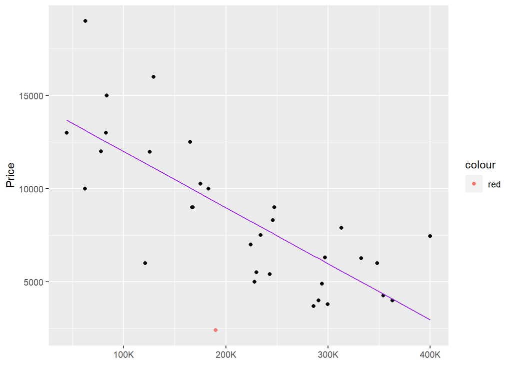

```
##  [1]  9945.155  7596.572  9722.966 11216.021 11109.656 13119.022  8134.331
##  [8] 11357.510  8074.085  7953.592  9971.844  7682.483  4067.703  6387.187
## [15] 10032.090  9489.873  8241.359  7543.826 13662.414 13126.402 12652.475
## [22] 12506.618 12490.050  2955.646  4338.812  4518.406  4989.171  5573.862
## [29]  5976.608  6054.658  6146.202  6250.398
```

```r
library(scales)
clm <- lm(Price ~ Mileage, data=cateye)
c <- coef(clm)
value_f <- function(x){
  y = c[1] + c[2]*x
  print(y)
}

# p <- ggplot(data=cateye) +
#   geom_point(mapping= aes(x=Mileage,
#                            y=Price)) +
#   geom_point(aes(x=190000,
#                  y= 2400, color="red")) +
#   geom_line(aes(x=Mileage,
#                 y=value_f(Mileage)),color="purple") +
#   xlab("Mileage (1K)")+
#   # this scale_x_continuous alters the x axis to but a K in there
#   scale_x_continuous(name=NULL, labels = label_number(scale_cut = cut_short_scale()))

p
```

We can look at the scatter plot above and the linear regression model being displayed in purple, there seems to be an inverse relationship between mileage and price, as mileage goes up price goes down.

#### Our LM values

```r
pander(summary(clm))
```

|  | Estimate | Std. Error | t value | Pr(>\|t\|) |
| --- | --- | --- | --- | --- |
| **(Intercept)** | 15002 | 1056 | 14.21 | 7.272e-15 |
| **Mileage** | -0.03012 | 0.00446 | -6.754 | 1.73e-07 |

Fitting linear model: Price ~ Mileage

| Observations | Residual Std. Error | $R^2$ | Adjusted $R^2$ |
| --- | --- | --- | --- |
| 32 | 2499 | 0.6033 | 0.5901 |

When we look at the table above we see the **intercept** of $15002$ and a **slope** of $-0.03012$. When looking further we can see that our $p-value$ of our intercept is $7.272e-15$ which is smaller than our $\alpha$ of $0.05$ This leads us to conclude that the intercept within this situation rejects the null hypothesis implying that there is enough evidence to say there’s a significant effect of the intercept. When looking at the slope we can see that we have a $p-value$ of $1.73e-07$ which is $<$ than the significance level of $\alpha = 0.05$. From this we can conclude that we can reject the null hypothesis, there is enough evidence to conclude that there is a significant linear relationship between the average price and mileage.

We can take the given values from the summary and create our mathimatical equation for Y.

#### Residuals

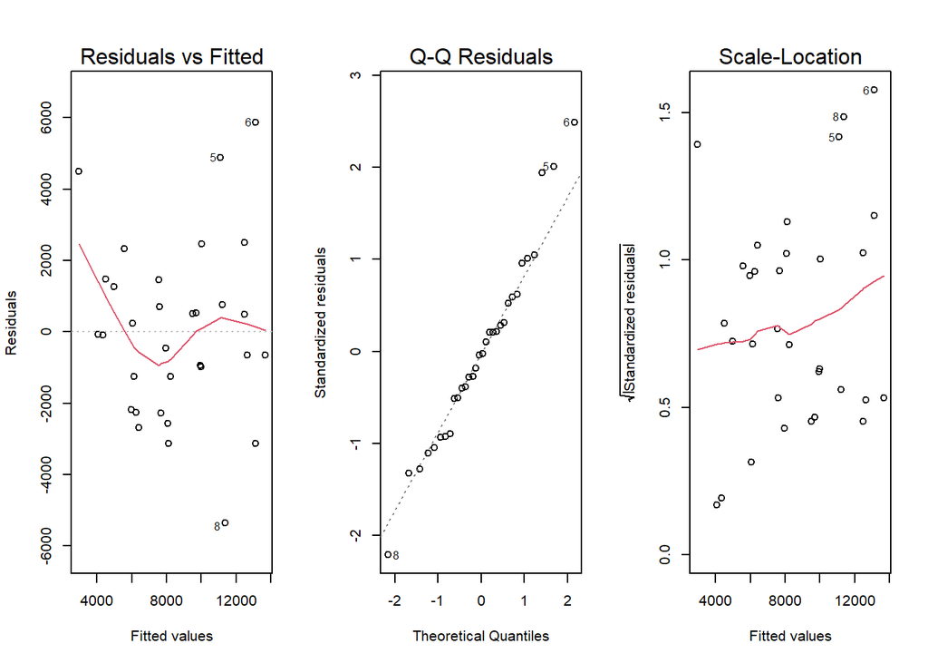

```r
par(mfrow=c(1,3))
plot(clm, which=1)
plot(clm, which=2)
plot(clm, which=3)
```

When looking at the residual plots they honestly look rather decent, the Residuals v. Fitted graph apears to have a strong pull up on the left side, there doesn’t appear to be a real strong pull or pattern going one way or the other. The Q-Q plot seems to have some problems towards the far right with normality.

### Cox Box

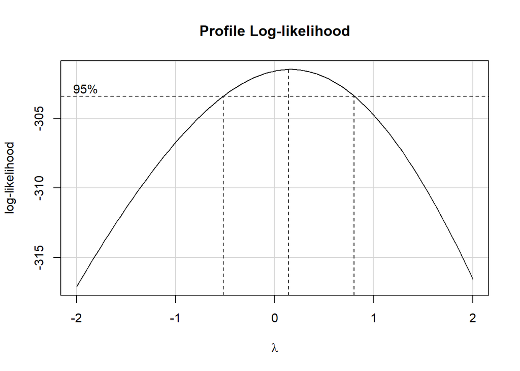

```r
boxCox(clm)
```

```r
# cat.lm.l <- lm(log(Price) ~ Mileage, data=cateye)
# cat.lm.s <- lm(sqrt(Price) ~ Mileage, data=cateye)
# cat.lm.ss <- lm(sqrt(sqrt(Price)) ~ Mileage, data=cateye)
```

### Transitional Lines Compared

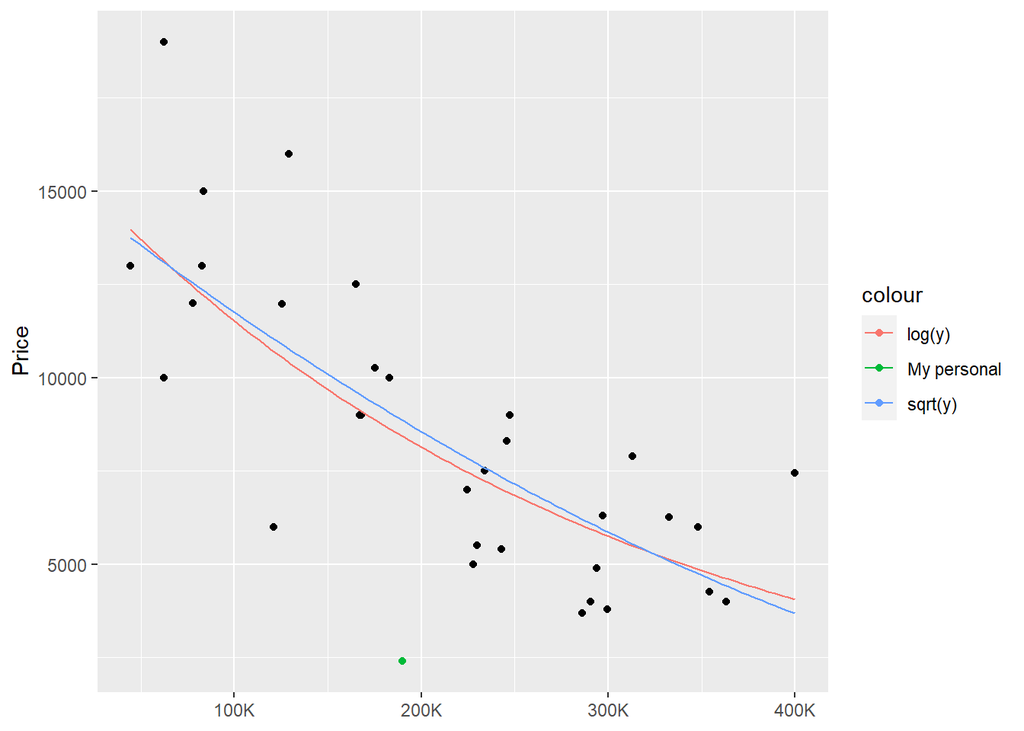

```r
# bl <- coef(cat.lm.l)
# bs <- coef(cat.lm.s)
# bss <- coef(cat.lm.ss)

# cp <- ggplot(data=cateye) +
#   geom_point(mapping= aes(x=Mileage,
#                            y=Price)) +
#   stat_function(fun=function(x) {exp(bl[1] + bl[2]*(x))}, aes(color="log(y)")) +
#   geom_point(mapping= aes(x=190000,
#                  y= 2400, color="My personal")) +
#   geom_line(mapping = aes(x=Mileage,
#                 y=value_f(Mileage)),color="purple") +
#   xlab("Mileage (1K)") +
#   scale_x_continuous(name=NULL, labels = label_number(scale_cut = cut_short_scale()))

cp +
  stat_function(fun=function(x) {(bs[1] + bs[2]*x)^2}, aes(color="sqrt(y)"))
```

Our New Plot would look as such:

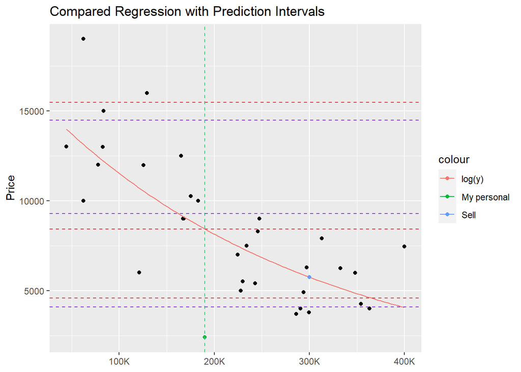

```r
# log_pi <- exp(predict(cat.lm.l, data.frame(Mileage=190000), interval="prediction"))
# log_ci  <- exp(predict(cat.lm.l, data.frame(Mileage=190000), interval="confidence"))
# lm_pi <- (predict(clm, data.frame(Mileage=190000), interval="prediction"))
# lm_ci <- (predict(clm, data.frame(Mileage=190000), interval="confidence"))
#
# cateye_plot <- cp +
#   geom_vline(xintercept = 190000, linetype= "dashed", color="seagreen3") +
#   geom_hline(yintercept = log_pi[,2], linetype="dashed", color="firebrick2") +
#   geom_hline(yintercept = log_pi[,3], linetype="dashed", color="firebrick2") +
#   geom_hline(yintercept = log_pi[,1], linetype="dashed", color="firebrick2") +
#   geom_hline(yintercept = lm_pi[,2], linetype="dashed", color="purple2") +
#   geom_hline(yintercept = lm_pi[,3], linetype="dashed", color="purple2")+
#   geom_hline(yintercept = lm_pi[,1], linetype="dashed", color="purple2") +
#   ggtitle("Compared Regression with Prediction Intervals") +
#   xlab("Vehicle Mileage")

cateye_plot+
  geom_point(aes(x=300000, y= selling_point[1], color="Sell"))
```

The red $ln{x}$ line seems to have a better portrayed curve and estimation of the value.

```r
summary(cat.lm.l) %>%
  pander()
```

|  | Estimate | Std. Error | t value | Pr(>\|t\|) |
| --- | --- | --- | --- | --- |
| **(Intercept)** | 9.699 | 0.1237 | 78.4 | 2.856e-36 |
| **Mileage** | -3.475e-06 | 5.227e-07 | -6.648 | 2.312e-07 |

Fitting linear model: log(Price) ~ Mileage Above we can see our logistic transformation of our model. We can express this through the following regression equation:

| Observations | Residual Std. Error | $R^2$ | Adjusted $R^2$ |
| --- | --- | --- | --- |
| 32 | 0.2929 | 0.5957 | 0.5822 |

### Confidence Intervals

```r
confidence <- data.frame(
  "Meaning" = c("Predicted Value", "2.5%", "97.5%"),
  "logrithmic model" = c(log_pi[,1], log_pi[,2], log_pi[,3]),
  "linear model" = c(lm_pi[,1], lm_pi[,2], lm_pi[,3])
)
diff <- data.frame(
  "Model" = c("Logrithmic Model", "Linear Model"),
  "Predicted Value" = c(log_pi[,1],lm_pi[,1]),
  "2.5%" = c(log_pi[,2],lm_pi[,2]),
  "97.5" = c(log_pi[,3],lm_pi[,3])
)

pander(diff)
```

| Model | Predicted.Value | X2.5. | X97.5 |
| --- | --- | --- | --- |
| Logrithmic Model | 8424 | 4586 | 15475 |
| Linear Model | 9279 | 4091 | 14467 |

When we look at the actual values of the confidence intervals in the table above we can see that the predicted values have a difference of $855$ in value based off our model predictions.An interesting thing to note is that our logarithmic interval band has both the lower and higher bands sitting above the Linear models band, when the linear models predictions value sits higher in comparison.

# Conclusion

```r
pred <- function(x) {
  exp(bl[1] + bl[2]*x)
}
# pred(1650000)
# pred(1000000)
#
# pred(193000)
# pred(300000)
pred_temp_df <- data.frame("Valuation" = c("Scrap Price", "Scrap-Price", "Current Value", "Would Sell Point"),
                           "Mileage" = c("1.65M","1M","190k","300k"),
                           "Estimated Price" = c(pred(1650000),pred(1000000),pred(190000),pred(300000)))
pander(pred_temp_df)
```

| Valuation | Mileage | Estimated.Price |
| --- | --- | --- |
| Scrap Price | 1.65M | 52.73 |
| Scrap-Price | 1M | 504.7 |
| Current Value | 190k | 8424 |
| Would Sell Point | 300k | 5748 |

An important aspect to note is that some of these figures may seem outlandish. The question arises, ‘Who would pay anything for a pickup with over 1M miles?’ The obvious answer is no one intending to drive it. However, it’s worth acknowledging that there are pickups that achieve the 1M miles club, typically equipped with diesel motors. Diesel engines have their own set of reasons and criteria that make such longevity more likely than with gas engines.

The purpose of the above table is to examine possible price points at which I could sell my vehicle and still equate to scrapping price. It’s noteworthy that the maximum mileage for a pickup being sold in this dataset reaches 400k, which is still promising and suggests their capability to reach such distances. It’s crucial to recognize that many other factors within the vehicle’s history, which are not addressed here, play a role in its overall condition and market value.